# R Notebook on Apriori Association learning rule analysis

Import libraries

```r
#install.packages('arules')
library(arules)
```

Data preprocessing Phrase

```r
dataset = read.csv('Market_Basket_Optimisation.csv', header = FALSE)
## Changing the data into the apriori dataset format
dataset = read.transactions('Market_Basket_Optimisation.csv', sep = ',', rm.duplicates = TRUE)
```

```
distribution of transactions with duplicates:
1
5
```

The data set contains the list of items bought by customers at a grocery store for a week. Note: A total number of 7501 customers list of purchase items were recorded with one of the customers buying the most items of 20 items. 5 transactions containing one duplicate was observed in the data and removed from the data set.

```r
summary(dataset)
```

```
transactions as itemMatrix in sparse format with
 7501 rows (elements/itemsets/transactions) and
 119 columns (items) and a density of 0.03288973

most frequent items:
mineral water          eggs     spaghetti  french fries     chocolate
         1788          1348          1306          1282          1229
      (Other)
        22405

element (itemset/transaction) length distribution:
sizes
   1    2    3    4    5    6    7    8    9   10   11   12   13   14   15
1754 1358 1044  816  667  493  391  324  259  139  102   67   40   22   17
  16   18   19   20
   4    1    2    1

   Min. 1st Qu.  Median    Mean 3rd Qu.    Max.
  1.000   2.000   3.000   3.914   5.000  20.000

includes extended item information - examples:
```

|  | labels |
| --- | --- |
| 1 | almonds |
| 2 | antioxydant juice |
| 3 | asparagus |

The dataset contains 7501 transactions (or shopping baskets), with each containing some combination of 119 distinct items. The data is also stored in a sparse matrix format to save memory because the matrix is mostly empty (only about 3.29% of the possible item-purchase pairs are non-zero).

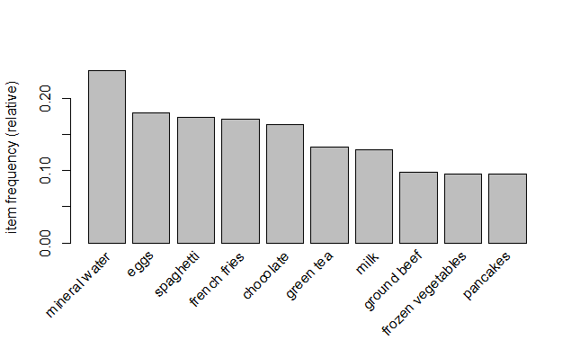

```r
itemFrequencyPlot(dataset, topN = 10)
```

```r
# Training Apriori on the dataset
rules = apriori(data = dataset, parameter = list(support = 0.004, confidence = 0.2))
```

```
Apriori

Parameter specification:
```

|  | confidence | minval | smax | arem | aval | originalSupport | maxtime | support | minlen | maxlen | target | ext |
| --- | --- | --- | --- | --- | --- | --- | --- | --- | --- | --- | --- | --- |
|  | 0.2 | 0.1 | 1 | none | FALSE | TRUE | 5 | 0.004 | 1 | 10 | rules | TRUE |

```
Algorithmic control:
```

|  | filter | tree | heap | memopt | load | sort | verbose |
| --- | --- | --- | --- | --- | --- | --- | --- |
|  | 0.1 | TRUE | TRUE | FALSE | TRUE | 2 | TRUE |

```
Absolute minimum support count: 30

set item appearances ...[0 item(s)] done [0.00s].
set transactions ...[119 item(s), 7501 transaction(s)] done [0.01s].
sorting and recoding items ... [114 item(s)] done [0.00s].
creating transaction tree ... done [0.00s].
checking subsets of size 1 2 3 4 done [0.01s].
writing ... [811 rule(s)] done [0.01s].
creating S4 object  ... done [0.00s].
```

The minimum support threshold for generating frequent item sets is set to 30, meaning any item set must appear in at least 30 transactions to be considered frequent. The algorithm checks all item sets of sizes 1 to 4 (combinations of 1, 2, 3, and 4 items) to find those that meet the minimum support of 30. After filtering based on support, 114 items remain for further analysis. Some items might have been excluded because they didn’t meet the minimum support of 30 transactions. The algorithm generated 811 association rules based on the frequent item sets it found. These rules show relationships between items that are often purchased together.

```r
# Visualising the results
inspect(sort(rules, by = 'lift')[1:10])
```

```
     lhs                       rhs                 support confidence   coverage     lift count
[1]  {light cream}          => {chicken}       0.004532729  0.2905983 0.01559792 4.843951    34
[2]  {pasta}                => {escalope}      0.005865885  0.3728814 0.01573124 4.700812    44
[3]  {pasta}                => {shrimp}        0.005065991  0.3220339 0.01573124 4.506672    38
[4]  {eggs,
      ground beef}          => {herb & pepper} 0.004132782  0.2066667 0.01999733 4.178455    31
[5]  {whole wheat pasta}    => {olive oil}     0.007998933  0.2714932 0.02946274 4.122410    60
[6]  {herb & pepper,
      spaghetti}            => {ground beef}   0.006399147  0.3934426 0.01626450 4.004360    48
[7]  {herb & pepper,
      mineral water}        => {ground beef}   0.006665778  0.3906250 0.01706439 3.975683    50
[8]  {tomato sauce}         => {ground beef}   0.005332622  0.3773585 0.01413145 3.840659    40
[9]  {mushroom cream sauce} => {escalope}      0.005732569  0.3006993 0.01906412 3.790833    43
[10] {frozen vegetables,
      mineral water,
      spaghetti}            => {ground beef}   0.004399413  0.3666667 0.01199840 3.731841    33
```

For example, let us interpret the first item set lhs rhs support confidence coverage lift count [1] {light cream} => {chicken} 0.004532729 0.2905983 0.01559792 4.843951 34 This means that there is a positive association of 4.8 between a customer buying light cream and chicken togther and its appear 0.004 times covering 34 in the transaction. Also, there is a probability (chance) of 0.3 for a customer who buy light cream to also buy chicken.

```r
# Training Apriori on the dataset
rules2 = apriori(data = dataset, parameter = list(support = 0.003, confidence = 0.5))
```

```
Apriori

Parameter specification:
```

|  | confidence | minval | smax | arem | aval | originalSupport | maxtime | support | minlen | maxlen | target | ext |
| --- | --- | --- | --- | --- | --- | --- | --- | --- | --- | --- | --- | --- |
|  | 0.5 | 0.1 | 1 | none | FALSE | TRUE | 5 | 0.003 | 1 | 10 | rules | TRUE |

```
Algorithmic control:
```

|  | filter | tree | heap | memopt | load | sort | verbose |
| --- | --- | --- | --- | --- | --- | --- | --- |
|  | 0.1 | TRUE | TRUE | FALSE | TRUE | 2 | TRUE |

```
Absolute minimum support count: 22

set item appearances ...[0 item(s)] done [0.00s].
set transactions ...[119 item(s), 7501 transaction(s)] done [0.01s].
sorting and recoding items ... [115 item(s)] done [0.00s].
creating transaction tree ... done [0.00s].
checking subsets of size 1 2 3 4 5 done [0.01s].
writing ... [83 rule(s)] done [0.00s].
creating S4 object  ... done [0.00s].
```

The minimum support threshold for generating frequent item sets is set to 22, in order to capture item that appears in least 22 transactions. The algorithm checks all item sets of sizes 1 to 5 (combinations of 1, 2, 3, 4,and 5 items) to generated 83 association rules based on the frequent item sets it found and the relationship between the items bought togther. After filtering based on support, 115 items remain for further analysis.

```r
# Visualising the results
inspect(sort(rules2, by = 'lift')[1:10])
```

```
     lhs                     rhs                 support confidence    coverage     lift count
[1]  {frozen vegetables,
      mineral water,
      soup}               => {milk}          0.003066258  0.6052632 0.005065991 4.670863    23
[2]  {frozen vegetables,
      mineral water,
      olive oil}          => {milk}          0.003332889  0.5102041 0.006532462 3.937285    25
[3]  {cereals,
      ground beef}        => {spaghetti}     0.003066258  0.6764706 0.004532729 3.885303    23
[4]  {frozen vegetables,
      soup}               => {milk}          0.003999467  0.5000000 0.007998933 3.858539    30
[5]  {chicken,
      olive oil}          => {milk}          0.003599520  0.5000000 0.007199040 3.858539    27
[6]  {olive oil,
      tomatoes}           => {spaghetti}     0.004399413  0.6111111 0.007199040 3.509912    33
[7]  {ground beef,
      tomato sauce}       => {spaghetti}     0.003066258  0.5750000 0.005332622 3.302508    23
[8]  {cooking oil,
      ground beef}        => {spaghetti}     0.004799360  0.5714286 0.008398880 3.281995    36
[9]  {ground beef,
      mineral water,
      tomatoes}           => {spaghetti}     0.003066258  0.5609756 0.005465938 3.221959    23
[10] {frozen vegetables,
      milk,
      soup}               => {mineral water} 0.003066258  0.7666667 0.003999467 3.216312    23
```